# 통계적 추정

```python
import numpy as np
import pandas as pd
import matplotlib.pyplot as plt
from scipy import stats

%precision 3
%matplotlib inline
```

```python
import os
os.getcwd()
```

```
'C:\\Users\\이찬솔\\Documents\\Python_Statistics'
```

```python
df = pd.read_csv('python_stat_sample-master/data/ch4_scores400.csv')
df.head()
```

|  | score |
| --- | --- |
| 0 | 76 |
| 1 | 55 |
| 2 | 80 |
| 3 | 80 |
| 4 | 74 |

```python
scores = np.array(df['score'])
scores.shape
```

```
(400,)
```

```python
p_mean = np.mean(scores)
p_var = np.var(scores)
p_mean, p_var
```

```
(69.530, 206.669)
```

#### 데이터의 히스토그램과 $N(\mu, \sigma^2)$ 그래프

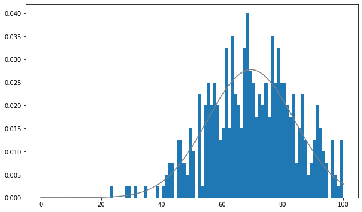

```python
fig = plt.figure(figsize = (10, 6))
ax = fig.add_subplot(111)

xs = np.arange(101)
rv = stats.norm(p_mean, np.sqrt(p_var))

ax.plot(xs, rv.pdf(xs), color = 'gray')
ax.hist(scores, bins = 100, range = (0, 100), density = True)

plt.show()
```

- 정규분포에 가까운 특징을 지닌 분포임을 확인

#### n = 20의 표본

```python
np.random.seed(0)
n = 20
sample = np.random.choice(scores, n)
sample
```

```
array([49, 60, 72, 86, 52, 61, 77, 91, 80, 56, 69, 67, 90, 56, 75, 79, 60,
       79, 68, 81], dtype=int64)
```

#### n = 20인 표본을 10000번 추출

```python
np.random.seed(1111)
n_samples = 10000
samples = np.random.choice(scores, (n_samples, n))
samples.shape
```

```
(10000, 20)
```

## 모평균의 점추정

- 무작위추출로 얻은 n = 20의 표본은, 기댓값이 $\mu$, 분산이 $\sigma^2$인 확률분포를 따르고, 서로 독립인 확률변수 $X_1, X_2, ... X_20$이라고 가정
- 표본평균 $\bar{X} = {{X_1 + X_2 + ... + X_n} \over n}$도 확률변수가 되고, 시행할 때마다 얻게 되는 결과는 다름
- 표본평균 $\bar{X}$의 기댓값 : $E(\bar{X}) = \mu$ => 모평균과 일치

### 불편성 : 추정량의 기댓값이 추측하려는 모수가 되는 성질

### 불편추정량 : 불편성을 가진 추정량

```python
for i in range(5):
    s_mean = np.mean(samples[i])
    print(f'{i+1}번째 표본평균: {s_mean:.3f}')
```

```
1번째 표본평균: 67.000
2번째 표본평균: 72.850
3번째 표본평균: 69.200
4번째 표본평균: 64.450
5번째 표본평균: 72.650
```

#### 10000개의 표본 각각에 대해 표본평균 계산 => 평균 (표본평균의 평균)

```python
sample_means = np.mean(samples, axis = 1)
sample_means.shape, np.mean(sample_means)
```

```
((10000,), 69.538)
```

### 일치성 : 표본크기 n을 증가시키면 추측하기 원하는 모수에 수렴

### 일치추정량 : 일치성을 가진 추정량

#### 모집단에서 100만번의 추출한 표본들의 평균 $E(\bar{X})$ => 모평균에 가까운 값 => 일치추정량

```python
np.mean(np.random.choice(scores, int(1e6)))
```

```
69.542954
```

#### 표본평균 ($\bar{X}$)

```python
s_mean = np.mean(sample)
s_mean
```

```
70.400
```

## 모분산의 점추정

#### 표본분산 ${1 \over n} \sum_{i = 1}^n (X_i - \bar{X})^2$은 확률변수 => 시행할 때마다 결과가 달라짐

```python
for i in range(5):
    s_var = np.var(samples[i])
    print(f'{i+1}번째 표본분산: {s_var:.3f}')
```

```
1번째 표본분산: 116.800
2번째 표본분산: 162.928
3번째 표본분산: 187.060
4번째 표본분산: 149.148
5번째 표본분산: 111.528
```

#### n = 20의 표본의 표본평균

```python
s_mean = np.mean(sample)
s_mean
```

```
70.400
```

### 불편분산 : 모분산의 불편추정량

### $s^2 = {1 \over {n-1}} \sum^n_{i=1}(X_i - \bar{X})^2$

#### 자유도 : 자유롭게 값을 취할 수 있는 변수의 개수

- **표본평균이라면 식 안의 $\sum^n_{i=1}X_i$에는 아무런 제약이 없고, 각 X가 자유롭게 값을 취함 => 자유도 n**
- **분산의 경우에는 식 안의 $\sum^n_{i=1} (X_i - \bar{X})^2$에서 각 $X_i$가 ${1 \over n} \sum^n_{i=1}X_i = \bar{X}$를 만족해야 하는 제약이 발생 => 자유도 n - 1**

### `np.var(data, axis, ddof)`

- `ddof` : 자유도의 차이 **본래의 자유도 n과의 차이**

#### 불편분산의 기댓값 계산 => 모분산에 근사한 값 (불편추정량)

```python
sample_u_vars = np.var(samples, axis = 1, ddof = 1)
np.mean(sample_u_vars)
```

```
206.678
```

#### **모집단에서 100만번의 추출한 표본들의 분산 => 모분산에 가까운 값 => 일치추정량**

```python
np.var(np.random.choice(scores, int(1e6)), ddof = 1)
```

```
207.083
```

#### n = 20의 표본의 불편분산 ($s^2$)

```python
u_var = np.var(sample, ddof = 1)
u_var
```

```
158.253
```

### 정리

#### 불편성 : 기댓값이 추측하기 원하는 모수가 되는 성질

#### 일치성 : 표본크기를 키우면 추측하기 원하는 모수에 수렴

#### 모평균과 모분산의 점추정

- **$X_1, X_2, ..., X_n$이 서로 독립이고 기댓값이 $\mu$, 분산이 $\sigma^2$인 확률분포를 따를 때, 표본평균 $\bar{X}$와 불편분산 $s^2$은 모평균 $\mu$와 모분산 $\sigma^2$에 대해서 불편성과 일치성을 지닌 추정량이 됨**

## 정규분포의 모평균(모분산을 알고 있는)의 구간추정

### 표본평균 $\bar{X} \sim N(\mu, {\sigma^2 \over n})$

- **표본평균이라는 추정량은 기댓값 그 자체인 모평균 $\mu$와 표준편차 ${\sigma^2 \over n}$으로 분산되어 있음**

### 표본오차 : 추정량의 표준편차 ${\sigma \over \sqrt{n}}$

### 모분산 $\sigma^2$를 알고 있는 상황 => 표준오차 ${\sigma^2 \over n}$ 계산 가능 => 오차 예측 가능

### 표본평균 $\bar{X} \sim N(\mu, {\sigma^2 \over n})$이므로, $Z = {(\bar{X} - \mu) \over {\sqrt{{\sigma^2 \over n}}}}$으로 표준화가능 (표준정규분포 변환)

**=> $100(1-\alpha)$%구간 계산 가능**

### 모분산을 알고 있을 때 모평균의 신뢰구간

- **$X_1, X_2, ..., X_n \sim N(\mu, \sigma^2)$일 때 모분산 $\sigma^2$를 알고 있다면, 신뢰수준 $100(1-\alpha)\%$인 신뢰구간은**

### $[\bar{X} - z_{\alpha / 2}\sqrt{{\sigma^2 \over n}}, \;\;\; \bar{X} - z_{1-{\alpha / 2}}\sqrt{{\sigma^2 \over n}}] \;\; = \;\;$ [신뢰하한, 신뢰하한]

#### 신뢰수준 95% 신뢰구간 : 모평균 $\mu$를 포함하는 확률이 95%인 구간

- $P(z_{0.975} \; \leq \; (\bar{X} - \mu) \; / \; \sqrt{{\sigma^2 \over n}} \; \leq \; z_{0.025}) = 0.95$ => $P(\bar{X} - z_{0.025}\sqrt{{\sigma^2 \over n}} \; \leq \; \mu \; \; \leq \; \bar{X} - z_{0.975})\sqrt{{\sigma^2 \over n}} = 0.95$
- $[\bar{X} - z_{0.025}\sqrt{{\sigma^2 \over n}}, \bar{X} - z_{0.975})\sqrt{{\sigma^2 \over n}}] \;\; = \;\;$ [신뢰하한, 신뢰하한]

#### 모평균의 95% 신뢰구간 => 모평균 69.53이 구간내에 포함

```python
rv = stats.norm(0, 1)
lcl = s_mean - rv.isf(0.025) * np.sqrt(p_var / n)
ucl = s_mean - rv.isf(0.975) * np.sqrt(p_var / n)

lcl, ucl, s_mean
```

[output not shown]

### 신뢰구간의 계산을 20번 수행 => 그중 몇 번 모평균을 포함하는지 시각화

- 중앙의 서직선은 모평균, 모평균을 포함하지 않은 구간추정은 다른 색으로 표시

#### **20번 중 모평균을 포함하지 않는 구간추정은 1번 => 95% 신뢰구간**

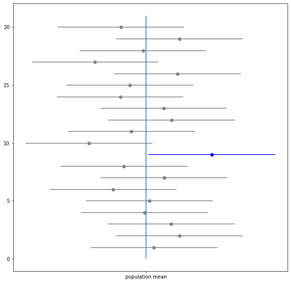

```python
fig = plt.figure(figsize = (10, 10))
ax = fig.add_subplot(111)

rv = stats.norm()
n_samples = 20
ax.vlines(p_mean, 0, 21)

for i in range(n_samples):
    sample_ = samples[i]
    s_mean_ = np.mean(sample_)
    lcl = s_mean_ - rv.isf(0.025) * np.sqrt(p_var / n)
    ucl = s_mean_ - rv.isf(0.975) * np.sqrt(p_var / n)

    if lcl <= p_mean <= ucl:
        ax.scatter(s_mean_, n_samples - i, color = 'gray')
        ax.hlines(n_samples-i, lcl, ucl, color = 'gray')
    else:
        ax.scatter(s_mean_, n_samples - i, color = 'b')
        ax.hlines(n_samples-i, lcl, ucl, color = 'b')


ax.set_xticks([p_mean])
ax.set_xticklabels(['population mean'])

plt.show()
```

### 신뢰구간의 계산을 10000번 수행 => 신뢰구간에 모평균이 포함된 것은 몇 %인지 시뮬레이션

#### 신뢰구간의 약 95%가 모평균을 포함

```python
rv = stats.norm(0, 1)
cnt = 0
```

```python
for sample_ in samples:
    s_mean_ = np.mean(sample_)
    lcl = s_mean_ - rv.isf(0.025) * np.sqrt(p_var / n)
    ucl = s_mean_ - rv.isf(0.975) * np.sqrt(p_var / n)

    if lcl <= p_mean <= ucl:
        cnt += 1


cnt / len(samples)
```

```
0.951
```

## 정규분포의 모평균(모분산을 모르는)의 구간추정

### 모분산 $\sigma^2$를 알지 못하기에 표준오차 $\sqrt{{\sigma^2 \over n}}$를 계산할 수 없음

### => 모분산 $\sigma^2$대신 불편분산 $\sqrt{{s^2 \over n}}$를 사용하여 표본평균 $\bar{X}$에 대해서 t변환

### $t = {{\bar{X} - \mu} \over {\sqrt{s^2 \over n}}}$

### t는 표준정규분포를 따르지 않음

### **$Z = {(\bar{X} - \mu) \over {\sqrt{{\sigma^2 \over n}}}}$와 비교시 => $T = Z / \sqrt{{s^2 \over \sigma^2}}$**

### ${s^2 \over \sigma^2}$는 카이제곱분포의 관계식 $Y = {{(n-1)s^2} \over \sigma^2}$을 사용함으로써 ${{(n-1)}\over \sigma^2} = {Y \over {n-1}}$

### => 결국 t는 표준정규분포 Z와 자유도 n-1인 카이제곱분포 Y에 의해 $t = {Z \over {\sqrt{Y / (n-1)}}}$이며, 자유도 n-1인 t분포를 따름

### 모분산을 모를 때 모평균의 신뢰구간

- **$X_1, X_2, ..., X_n \sim N(\mu, \sigma^2)$일 때 모분산 $\sigma^2$를 모른다면, 신뢰수준 $100(1-\alpha)\%$인 신뢰구간은**

### $[\bar{X} - t_{\alpha / 2}(n-1)\sqrt{{s^2 \over n}}, \;\;\; \bar{X} - t_{1-{\alpha / 2}}(n-1)\sqrt{{s^2 \over n}}] \;\; = \;\;$ [신뢰하한, 신뢰하한]

#### 신뢰수준 95% 신뢰구간 : 모평균 $\mu$를 포함하는 확률이 95%인 구간

- $P(t_{0.975}(n-1) \; \leq \; (\bar{X} - \mu) \; / \; \sqrt{{s^2 \over n}} \; \leq \; t_{0.025}(n-1)) = 0.95$ => $P(\bar{X} - t_{0.025}(n-1)\sqrt{{s^2 \over n}} \; \leq \; \mu \; \; \leq \; \bar{X} - t_{0.975}(n-1))\sqrt{{s^2 \over n}} = 0.95$
- $[\bar{X} - t_{0.025}(n-1)\sqrt{{s^2 \over n}}, \bar{X} - t_{0.975}(n-1))\sqrt{{s^2 \over n}}] \;\; = \;\;$ [신뢰하한, 신뢰하한]

#### 모평균의 95% 신뢰구간 => 모평균 69.53이 구간내에 포함

```python
rv = stats.t(df = n - 1)
lcl = s_mean - rv.isf(0.025) * np.sqrt(u_var / n)
ucl = s_mean - rv.isf(0.975) * np.sqrt(u_var / n)

lcl, ucl
```

```
(64.512, 76.288)
```

## 정규분포의 모분산(모평균을 알지 못하는) 구간추정

### $P(* \; \leq \; \sigma^2 \; \leq \; *) = 0.95$

- **불편분산 $s^2$를 변환하여, 확률분포를 따르는 확률변수를 생성**

### 불편분산 $s^2$에 카이제곱 변환 : $Y = {{(n-1)s^2} \over \sigma^2}$ => $Y \sim \chi^2(n-1)$

- 1만개의 표본 데이터에서 Y의 표본 생성

```python
sample_y = sample_u_vars * (n-1) / p_var
sample_y.shape
```

```
(10000,)
```

### Y의 표본 히스토그램과 $\chi^2 (n-1)$의 밀도함수

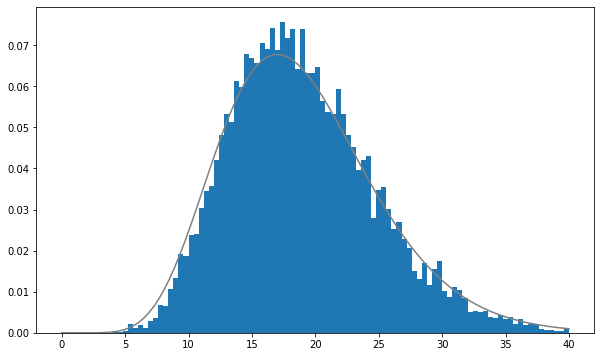

```python
fig = plt.figure(figsize = (10, 6))
ax = fig.add_subplot(111)

xs = np.linspace(0, 40, 100)
rv = stats.chi2(df = n - 1)

ax.plot(xs, rv.pdf(xs), color = 'gray')
hist, _, _ = ax.hist(sample_y, bins = 100,
                     range = (0, 40), density = True)

plt.show()
```

### 모분산의 구간추정

- **$X_1, X_2, ..., X_n \sim N(\mu, \sigma^2)$이라고 가정하고, 모평균 $\mu$를 모를 때, 신뢰수준 $100(1-\alpha)\%$인 신뢰구간은**

### [${{(n-1)s^2} \over {\chi^2_{\alpha / 2}(n-1)}}\;, \;\; {{(n-1)s^2} \over {\chi^2_{1 - \alpha / 2}(n-1)}} $]

#### $\chi^2 (n-1)$의 95% 신뢰구간

- $P(\chi^2_{0.975}(n-1) \; \leq \; {{(n-1)s^2} \over \sigma^2} \; \leq \; \chi^2_{0.025}(n-1) = 0.95$
- P(${{(n-1)s^2} \over {\chi^2_{\alpha / 2}(n-1)}} \; \leq \; \sigma^2 \; \leq \; {{(n-1)s^2} \over {\chi^2_{1-\alpha / 2}(n-1)}}$) = 0.95

#### 모분산의 95% 신뢰구간 => 모분산 206.669가 구간내에 포함

```python
rv = stats.chi2(df = n - 1)
lcl = (n-1) * u_var / rv.isf(0.025)
hcl = (n-1) * u_var / rv.isf(0.975)

lcl, hcl
```

```
(91.525, 337.596)
```

### 신뢰구간의 계산을 20번 수행 => 그중 몇 번 모분산을 포함하는지 시각화

#### **20번 중 모분산을 포함하지 않는 구간추정은 1번 => 95% 신뢰구간**

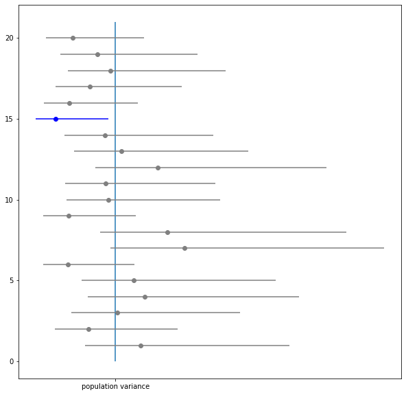

```python
fig = plt.figure(figsize = (10, 10))
ax = fig.add_subplot(111)

rv = stats.chi2(df = n - 1)
n_samples = 20

ax.vlines(p_var, 0, 21)
for i in range(n_samples):
    sample_ = samples[i]
    u_var_ = np.var(sample_, ddof = 1)
    lcl = (n-1) * u_var_ / rv.isf(0.025)
    ucl = (n-1) * u_var_ / rv.isf(0.975)

    if lcl <= p_var <= ucl:
        ax.scatter(u_var_, n_samples - i, color = 'gray')
        ax.hlines(n_samples - i, lcl, ucl, 'gray')
    else:
        ax.scatter(u_var_, n_samples - i, color = 'b')
        ax.hlines(n_samples - i, lcl, ucl, 'b')

ax.set_xticks([p_var])
ax.set_xticklabels(['population variance'])

plt.show()
```

### 신뢰구간의 계산을 10000번 수행 => 신뢰구간에 모분산이 포함된 것은 몇 %인지 시뮬레이션

#### 신뢰구간의 약 95%가 모분산을 포함

```python
rv = stats.chi2(df = n - 1)
cnt = 0
```

```python
for sample_ in samples:
    u_var_ = np.var(sample_, ddof = 1)
    lcl = (n-1) * u_var_ / rv.isf(0.025)
    ucl = (n-1) * u_var_ / rv.isf(0.975)

    if lcl <= p_var <= ucl:
        cnt += 1

cnt / len(samples)
```

```
0.964
```

### 모비율의 추정 (베르누이 분포의 모평균 구간추정)

- **$X_1, X_2, ..., X_n \sim Bern(p)$일 때, 모비율의 신뢰수준 $100(1-\alpha)\%$의 신뢰구간**

### [$\bar{X} - z_{\alpha / 2} \sqrt{{{\bar{X}(1-\bar{X})} \over n}}, \; \bar{X} - z_{1-\alpha / 2} \sqrt{{{\bar{X}(1-\bar{X})} \over n}}$]

### 베르누이 분포 표본평균 $\bar{X}$의 기댓값은 $p$, 분산은 $p(1-p) \over n$

#### 베르누이 분포 모평균의 95% 신뢰구간

- **베르누이 분포의 표본평균이 따르는 확률분포를 알지 못함 => 중심극한정리 사용**
- **중심극한정리에 따라 표본평균 $\bar{X}$는 근사적으로 $N(p, \; {{p(1-p)}\over n})$**를 따름
- **이를 표준화 => $Z = (\bar{X}-p) / \sqrt{(p(1-p) \over n}$로 변환 => Z는 표준정규분포를 따르는 것으로 간주**

#### $0.95 \simeq P(z_{0.975} \; \leq \; (\bar{X}-p) / \sqrt{(p(1-p) \over n} \; \leq \; z_{0.025})$

**= $P(\bar{X} - z_{0.025} \; \sqrt{(p(1-p) \over n} \; \leq \; p \; \leq \; \bar{X} - z_{0.975} \; \sqrt{(p(1-p) \over n})$**

**= $P(\bar{X} - z_{0.025} \; \sqrt{(\bar{X}(1-\bar{X}) \over n} \; \leq \; p \; \leq \; \bar{X} - z_{0.975} \; \sqrt{(\bar{X}(1-\bar{X}) \over n})$**

```python
enquete_df = pd.read_csv('python_stat_sample-master/data/ch10_enquete.csv')
enquete_df.shape
```

```
(1000, 1)
```

```python
enquete = np.array(enquete_df['known'])
n = len(enquete)
enquete[:10]
```

```
array([1, 0, 1, 1, 1, 1, 1, 0, 0, 1], dtype=int64)
```

#### 표본평균

```python
s_mean = enquete.mean()
s_mean
```

```
0.709
```

#### p의 95% 신뢰구간

```python
rv = stats.norm(0, 1)
lcl = s_mean - rv.isf(0.025) * np.sqrt(s_mean*(1-s_mean)/n)
ucl = s_mean - rv.isf(0.975) * np.sqrt(s_mean*(1-s_mean)/n)

lcl, ucl
```

```
(0.6808474522924337, 0.7371525477075662)
```

### 포아송 분포의 모평균의 구간추정

- **$X_1, X_2, ..., X_n$이 서로 독립이고 $\sim Poi(\lambda)$일 때, $Poi(\lambda)$의 기댓값과 분산은 모두 $\lambda$이었기 때문에, 표본평균 $\bar{X}$의 기댓값은 $\lambda$, 분산은 $\lambda \over n$**
- **$X_1, X_2, ..., X_n \sim Poi(\lambda)$일 때, 모평균의 신뢰수준 $100(1-\alpha)\%$의 신뢰구간**

### [$\bar{X}- z_{\alpha / 2} \sqrt{{\bar{X}} \over n} \; \leq \; \lambda \; \leq \; \bar{X}-z_{1-\alpha/2}\sqrt{{{\bar{X}}\over n}}$]

#### 포아송 분포 모평균의 95% 신뢰구간

- **포아송 분포의 표본평균이 따르는 확률분포를 알지 못함 => 중심극한정리 사용**
- **중심극한정리에 따라 표본평균 $\bar{X}$는 근사적으로 $N(\lambda, \; {\lambda \over n})$**를 따름
- **이를 표준화 => $Z = (\bar{X}-\lambda) / \sqrt{\lambda \over n}$로 변환 => Z는 표준정규분포를 따르는 것으로 간주**

#### $0.95 \simeq P(z_{0.975} \; \leq \; (\bar{X}-\lambda) / \sqrt{\lambda \over n} \; \leq \; z_{0.025})$

**= $P(\bar{X} - z_{0.025}\;\sqrt{\lambda \over n} \; \leq \; lambda \; \leq \; \bar{X} - z_{0.975} \; \sqrt{\lambda \over n})$**

**= $P(\bar{X} - z_{0.025} \; \sqrt{\bar{X} \over n} \; \leq \; \lambda \; \leq \; \bar{X} - z_{0.975} \; \sqrt{\bar{X} \over n})$**

```python
n_access_df = pd.read_csv('python_stat_sample-master/data/ch10_access.csv')
n_access_df.shape
```

```
(72, 1)
```

```python
n_access = np.array(n_access_df['access number'])
n = len(n_access)
n_access[:10]
```

```
array([10, 11,  9,  9, 18, 13,  4, 10, 10,  8], dtype=int64)
```

#### 표본평균 : 시간당 평균 사건 수

```python
s_mean = n_access.mean()
s_mean
```

```
10.444
```

#### $\lambda$의 95%신뢰구간

```python
rv = stats.norm(0, 1)
lcl = s_mean - rv.isf(0.025) * np.sqrt(s_mean / n)
ucl = s_mean - rv.isf(0.975) * np.sqrt(s_mean / n)

lcl, ucl
```

```
(9.698, 11.191)
```